# Practical Machine Learning

Lynette Garcia

31 de enero de 2016

## Introduction

One thing that people regularly do is quantify how much of a particular activity they do, but they rarely quantify how well they do it. In this project, we will using data from accelerometers on the belt, forearm, arm, and dumbell of 6 participants.  
## Preparing environment

### Loading Data and libraries

**Note**: The .csv files must be in your working directory

```r
training<- read.csv("pml-training.csv")
testing<- read.csv("pml-testing.csv")

#Loading libraries
library(caret)
library(rattle)

set.seed(54321)
```

## Preprocessing

First of all we did some preprosessing task to the training data set. We had to delete columns which all row values was NA. This preprocessing task was made in both data sets training and testing.

We splited the training dataset in two datasets in order to check the accuracy of algorithms

```r
#Creating a test set from training set to test models accuracy
inTrain<-createDataPartition(y=training$classe, p=0.7, list=FALSE)
trainingSet<-training[inTrain,]
testingSet<-training[-inTrain,]
dim(trainingSet); dim(testingSet)
```

```
## [1] 13737   160
```

```
## [1] 5885  160
```

Then, we did a near zero values test so we could omit non usefull predictors.

```r
#Near Zero Values
nzv<-nearZeroVar(trainingSet,saveMetrics = TRUE)

#Removing near zero variables
trainingSet<-trainingSet[,nzv$nzv==FALSE]
testingSet<-testingSet[,nzv$nzv==FALSE]
```

We deleted columns in which all values were NAs

```r
#Deleting Columns with NA in the training set
trainingSet <- trainingSet[, colSums(is.na(trainingSet)) == 0]
#deleting columns with NA in the testing set
testingSet <- testingSet[, colSums(is.na(testingSet)) == 0]
```

Then we omited id, usernames and timeStamp columns because it doesn’t had usefull information for prediction.

```r
trainingSet<-trainingSet[,-seq(1:5)]
testingSet<-testingSet[,-seq(1:5)]
```

We prepared the testing dataset in order to have the same columns than training dataset.

```r
testing<-testing[colnames(testingSet[,-54])]
```

## Fitting the models.

After that, we fitted several models.

#### Decision trees

```r
modelTree<-train(classe~.,data=trainingSet,method="rpart")
predTrees<-predict(modelTree,testingSet)
```

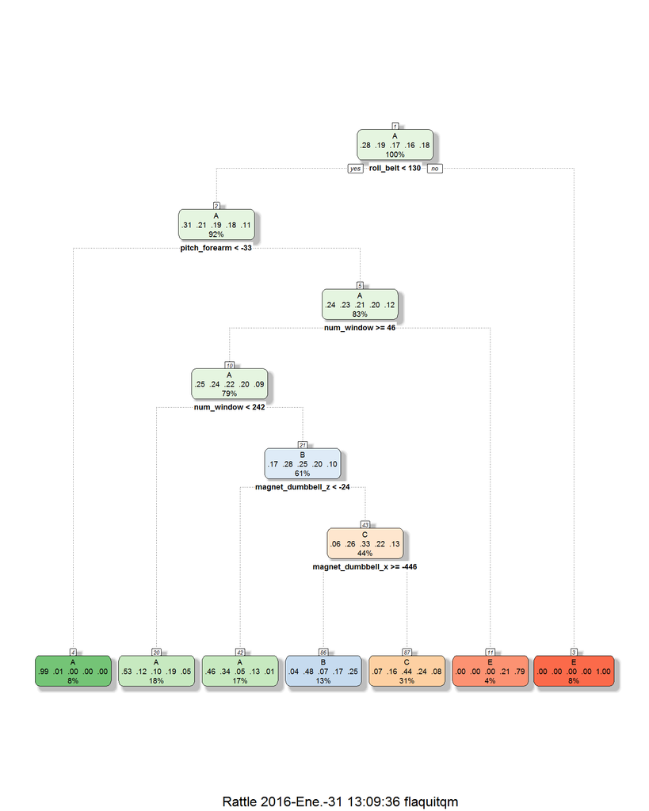

```r
fancyRpartPlot(modelTree$finalModel)
```

As you see this method doesn’t have a high accuracy with this data. So another methods were tested.

```r
cm<-confusionMatrix(testingSet$classe, predTrees)

cm$overall
```

```
##       Accuracy          Kappa  AccuracyLower  AccuracyUpper   AccuracyNull
##   5.568394e-01   4.273994e-01   5.440372e-01   5.695853e-01   4.377230e-01
## AccuracyPValue  McnemarPValue
##   3.395020e-75   0.000000e+00
```

```r
cm$table
```

```
##           Reference
## Prediction    A    B    C    D    E
##          A 1495   36  133    0   10
##          B  529  324  286    0    0
##          C  171   40  815    0    0
##          D  314  132  477    0   41
##          E   67  202  170    0  643
```

We fitted a random forest model

```r
fitControl <- trainControl(method="cv", number=3, verboseIter=F)
modelrf<-train(classe ~ .,data=trainingSet, method="rf", trControl=fitControl)
predrf<-predict(modelrf,newdata=testingSet)
```

As this method’s accuracy was **99%** it can be considered as a better approach for this problem.

[output not shown]

After training the model we can predict using the given testing data set.

```r
predTest<-predict(modelrf,newdata=testing)
data.frame(id=seq(1:20), classe=predTest)
```

[output not shown]